# Visualize: Layers, Exploratory Data Analysis, Communication

## Scale (4/4)

### Update the graphic to include the suggestions above

```r
date_limits = c(as_date("1980-01-01"), as_date("2025-01-01"))
date_breaks = seq(as_date("1980-01-01"), as_date("2025-01-01"), by = "5 years")

rmhi |>
  ggplot() +
  geom_line(aes(x = date, y = median_income), color = "blue") +
  labs(
    title = "Real Median Household Income in the United States",
    subtitle = "Units: CPI-U-RS Adjusted Dollars, Not Seasonally Adjusted",
    x = "Year",
    y = "2022 CPI-U-RS Adjusted Dollars",
    caption = "Source: U.S. Census Bureau"
  ) +
  scale_y_continuous(labels = scales::dollar) +
  scale_x_date(limits  = date_limits, breaks = date_breaks, date_labels = "%Y") +
  theme_linedraw()
```

## Themes (1/2)

### Themes give you considerable control over the appearance of your plot.

```r
date_limits = c(as_date("1980-01-01"), as_date("2025-01-01"))
date_breaks = seq(as_date("1980-01-01"), as_date("2025-01-01"), by = "5 years")

rmhi |>
  ggplot() +
  geom_line(aes(x = date, y = median_income), color = "blue") +
  labs(
    title = "Real Median Household Income in the United States",
    subtitle = "Units: CPI-U-RS Adjusted Dollars, Not Seasonally Adjusted",
    x = "Year",
    y = "2022 CPI-U-RS Adjusted Dollars",
    caption = "Source: U.S. Census Bureau"
  ) +
  scale_y_continuous(labels = scales::dollar) +
  scale_x_date(limits  = date_limits, breaks = date_breaks, date_labels = "%Y") +
  theme_linedraw()
```

### Proposed changes:

- Increase the font size of the title and make the subtitle italic.
- Change the font size of the x and y axis text.
- Move the title, subtitle, and caption to the left.
- Remove the x-axis and y-axis labels (use the subtitle for y-label).

Look at **?theme**

## Themes (2/2)

### Update the graphic to include the suggestions above

```r
date_limits = c(as_date("1980-01-01"), as_date("2025-01-01"))
date_breaks = seq(as_date("1980-01-01"), as_date("2025-01-01"), by = "5 years")

rmhi |>
  ggplot() +
  geom_line(aes(x = date, y = median_income), color = "blue") +
  labs(
    title = "Real Median Household Income in the United States",
    subtitle = "Units: CPI-U-RS Adjusted Dollars, Not Seasonally Adjusted",
    x = "Year",
    y = "2022 CPI-U-RS Adjusted Dollars",
    caption = "Source: U.S. Census Bureau"
  ) +
  scale_y_continuous(labels = scales::dollar) +
  scale_x_date(limits  = date_limits, breaks = date_breaks, date_labels = "%Y") +
  theme_linedraw()
```

[output not shown]

Updated visualization:

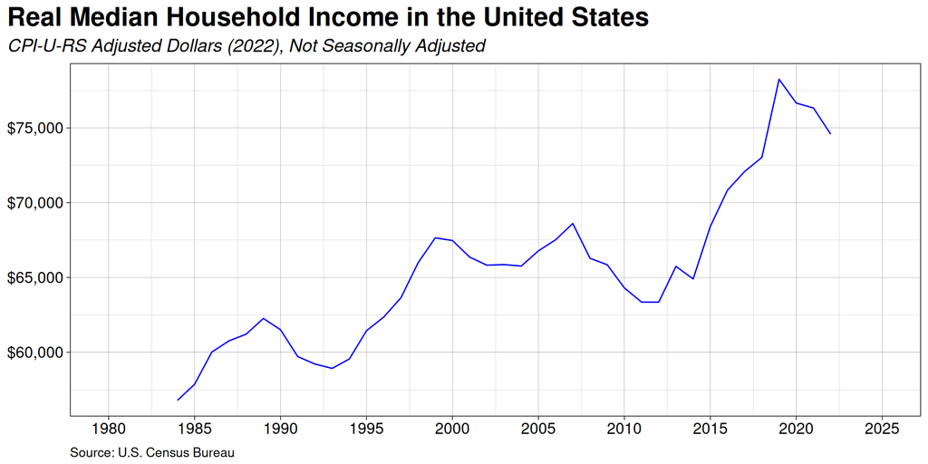

```r
date_limits = c(as_date("1980-01-01"), as_date("2025-01-01"))
date_breaks = seq(as_date("1980-01-01"), as_date("2025-01-01"), by = "5 years")

rmhi |>
  ggplot() +
  geom_line(aes(x = date, y = median_income), color = "blue") +
  labs(
    title = "Real Median Household Income in the United States",
    subtitle = "CPI-U-RS Adjusted Dollars (2022), Not Seasonally Adjusted",
    x = NULL,
    y = NULL,
    caption = "Source: U.S. Census Bureau"
  ) +
  scale_y_continuous(labels = scales::dollar) +
  scale_x_date(limits  = date_limits, breaks = date_breaks, date_labels = "%Y") +
  theme_linedraw() +
  theme(
    plot.title = element_text(size = 20, face = "bold", hjust = 0),
    plot.title.position = "plot",
    plot.subtitle = element_text(size = 14, face = "italic", hjust = 0),
    axis.title.x = element_blank(),
    axis.text = element_text(size = 12),
    axis.title.y = element_blank(),
    plot.caption = element_text(size = 10, hjust = 0, vjust = 0)
  )
```

## Layout (1/2)

### Patchwork!

[patchwork](https://patchwork.data-imaginist.com/)

> The goal of patchwork is to make it ridiculously simple to combine separate ggplots into the same graphic. As such it tries to solve the same problem as `gridExtra::grid.arrange()` and `cowplot::plot_grid` but using an API that incites exploration and iteration, and scales to arbitrarily complex layouts.

```r
library(patchwork)
```

## Layout (2/2)

### Combine the two plots

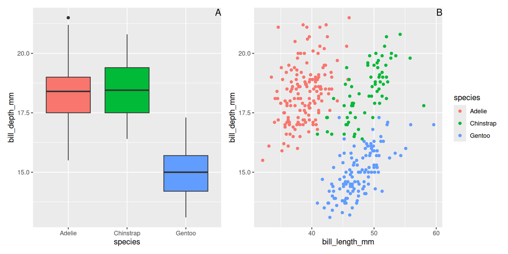

```r
p1 <- penguins |>
  ggplot() +
  geom_boxplot(aes(x = species, y = bill_depth_mm, fill = species), show.legend = FALSE) +
  labs(tag = "A") + theme(plot.tag.location = "panel", plot.tag.position = "topright")

p2 <- penguins |>
  ggplot() +
  geom_point(aes(x = bill_length_mm, y = bill_depth_mm, color = species)) +
  labs(tag = "B") +theme(plot.tag.location = "panel", plot.tag.position = "topright")

(p1 + p2) + plot_layout(guides = "collect")
```

## Assignment

### When Online Content Disappears

Recreate the plot from the article:

[Pew Research](https://www.pewresearch.org/data-labs/2024/05/17/when-online-content-disappears/)

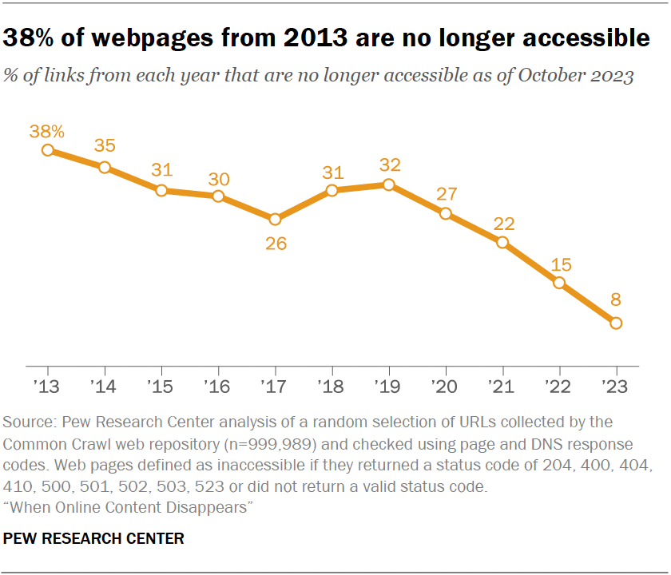

```r
# Font looks close to google font "work sans"

pew_data <- c(38, 35, 31, 30, 26, 31, 32, 27, 22, 15, 8)
years <- 2013:2023
color = "#ed9d09"

pew_df <- tibble(year = years, percent = pew_data)
pew_df
```

| year | percent |
| --- | --- |
| 2013 | 38 |
| 2014 | 35 |
| 2015 | 31 |
| 2016 | 30 |
| 2017 | 26 |
| 2018 | 31 |
| 2019 | 32 |
| 2020 | 27 |
| 2021 | 22 |
| 2022 | 15 |

[output cut: 1 more lines]

## Sandbox

[figure not shown]

```r
library(ggtext)

caption_text = paste(str_wrap("Source: Pew Research Center analysi of a random selection of URLs collected by the Common Crawl web repository (n=999,989) and checked using page and DNS response codes. Web pages defined as inaccessible if they returned a status code of 204, 400, 404, 410, 500, 501, 502, 503, 523 or did not return a valid status code.",
                 width = 86),
        "\n\"When Online Content Disappears\"")

pew_df |>
  ggplot() +
  geom_line(aes(x = year, y = percent), color = color, linewidth = 3) +
  geom_point(aes(x = year, y = percent), shape = 21 , color = color, fill = "white", size = 4, stroke = 1) +
  geom_text(aes(x = year, y = percent, label = paste0(percent, "%")), nudge_y = 2.2, nudge_x = 0.0, size = 4, color = color, data = filter(pew_df, year == 2013)) +
  geom_text(aes(x = year, y = percent, label = percent), nudge_y = 2.2, nudge_x = 0, size = 4, color = color, data = filter(pew_df, year >= 2014)) +
#  annotate("text", x = 2014.05, y = 5, label = "PEW RESEARCH CENTER", color = "black", size = 4, fontface = "bold") +
  labs(
    title = "38% of webpages from 2013 are no longer accessible",
    subtitle = "% of links from each year that are no longer accessible as of October 2023",
    x = "",
    y = NULL,
    caption = caption_text,
    tag = "PEW RESEARCH CENTER"
    ) +
  theme_minimal() +
  scale_y_continuous(limits = c(5, 42)) +
  scale_x_continuous(limits = c(2012.75, 2023.25), breaks = 2013:2023) +
  theme(
    plot.title = element_markdown(size = 20, face = "bold"),
    plot.title.position = "plot",
    plot.subtitle = element_markdown(size = 14, face = "italic", color = "#666666"),
    plot.caption = element_text(size = 12, face = "italic", hjust = 0, color = "#666666"),
    plot.caption.position = "plot",
    axis.text.x = element_text(size = 12),
    axis.line.x = element_line(color = "black"),
    axis.ticks.x = element_line(color = "black"),
    axis.text.y = element_blank(),
    plot.tag.location = "plot",
    plot.tag.position = "bottomright",
    plot.tag = element_text(size = 12, face = "bold", color = "black"),
    panel.grid = element_blank()
  )
```

# End of Module 4